# R Notebook

Call Libraries

```r
library(tidyverse)
library(janitor)
library(here)
library(readxl)
library(lubridate)
```

**Labour_Productivity-OECD_Countries**

Read data

```r
gdp_phw <- read_csv(here("raw_data/OECD_GDP_per_Hour_Worked_JHios.csv")) %>%
  clean_names()
glimpse(gdp_phw)
```

```
Rows: 3,814
Columns: 8
$ location   <chr> "AUS", "AUS", "AUS", "AUS", "AUS", "AUS", "AUS", "AUS", "AUS", "AUS", "AUS", "AUS", "AUS", "AUS", "AUS", "AUS", "AUS", "AUS", "AUS", "AU~
$ indicator  <chr> "GDPHRWKD", "GDPHRWKD", "GDPHRWKD", "GDPHRWKD", "GDPHRWKD", "GDPHRWKD", "GDPHRWKD", "GDPHRWKD", "GDPHRWKD", "GDPHRWKD", "GDPHRWKD", "GDP~
$ subject    <chr> "TOT", "TOT", "TOT", "TOT", "TOT", "TOT", "TOT", "TOT", "TOT", "TOT", "TOT", "TOT", "TOT", "TOT", "TOT", "TOT", "TOT", "TOT", "TOT", "TO~
$ measure    <chr> "USD", "USD", "USD", "USD", "USD", "USD", "USD", "USD", "USD", "USD", "USD", "USD", "USD", "USD", "USD", "USD", "USD", "USD", "USD", "US~
$ frequency  <chr> "A", "A", "A", "A", "A", "A", "A", "A", "A", "A", "A", "A", "A", "A", "A", "A", "A", "A", "A", "A", "A", "A", "A", "A", "A", "A", "A", "~
$ time       <dbl> 1970, 1971, 1972, 1973, 1974, 1975, 1976, 1977, 1978, 1979, 1980, 1981, 1982, 1983, 1984, 1985, 1986, 1987, 1988, 1989, 1990, 1991, 1992~
$ value      <dbl> 26.84966, 27.51984, 28.12699, 28.70706, 28.24612, 29.29258, 29.78026, 29.74578, 31.00299, 31.16227, 31.51076, 32.41978, 32.80942, 33.708~
$ flag_codes <chr> NA, NA, NA, NA, NA, NA, NA, NA, NA, NA, NA, NA, NA, NA, NA, NA, NA, NA, NA, NA, NA, NA, NA, NA, NA, NA, NA, NA, NA, NA, NA, NA, NA, NA, ~
```

Change time in datetime format

```r
gdp_phw <- gdp_phw %>%
  mutate(time = make_datetime(time))
```

Check for NA values

```r
gdp_phw %>%
  summarise(across(.cols = everything(),
                   .fns = ~sum(is.na(.x))))
```

| location | indicator | subject | measure | frequency | time | value | flag_codes |
| --- | --- | --- | --- | --- | --- | --- | --- |
| 0 | 0 | 0 | 0 | 0 | 0 | 0 | 3760 |

View data

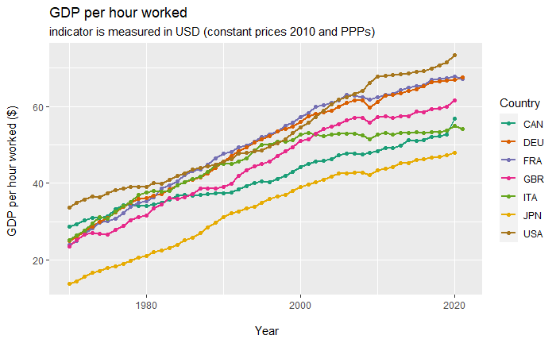

```r
gdp_phw %>%
  select(-c(indicator, subject, frequency, flag_codes)) %>%
  filter(
    location %in% c("CAN", "FRA", "DEU", "ITA", "JPN", "USA", "GBR"),
    measure == "USD") %>%
  ggplot() +
  aes(x = time, y = value, colour = location) +
  geom_line(size = 0.75) +
  geom_point(size = 1.5) +
  scale_colour_brewer(palette = "Dark2") +
  ggtitle(
    "GDP per hour worked",
    subtitle =  "indicator is measured in USD (constant prices 2010 and PPPs)"
  ) +
  labs(
    x = "\n Year",
    y = "GDP per hour worked ($) \n",
    colour = "Country"
  )
```

```r
NA
```

G-7 GDP per hour worked data

```r
gdp_phw_g7 <- gdp_phw %>%
  filter(
    location %in% c("CAN", "FRA", "DEU", "ITA", "JPN", "USA", "GBR"),
    measure == "USD"
  ) %>%
  select(-c(indicator, frequency, measure, subject, flag_codes)) %>%
  rename(gdp_phw_usd = value)
```

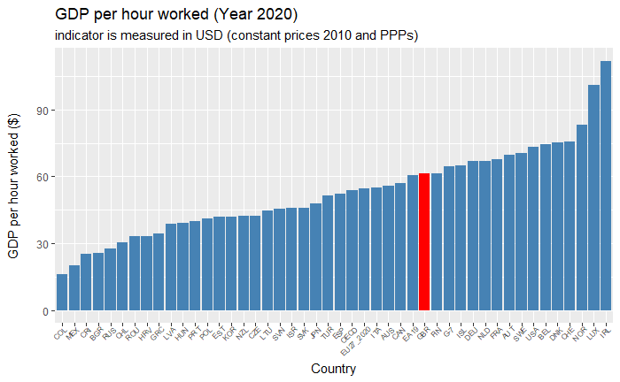

```r
gdp_phw %>%
  mutate(time = year(time)) %>%
  filter(
    # LOCATION %in% c("G-7", "EU28", "CAN", "FRA", "DEU", "ITA", "JPN", "USA", "GBR"),
    measure == "USD",
    time == 2020
    ) %>%
  select(-c(indicator, frequency, measure, subject, time, flag_codes)) %>%
  ggplot() +
  aes(
    x = reorder(location, value),
    y = value,
    fill = reorder(location, value) == "GBR"
    ) +
  geom_col() +
  scale_fill_manual(values = c('steelblue', 'red'), guide = "none") +
  theme(
    axis.text.x = element_text(size = 6, angle = 45, vjust = 1.15, hjust = 1) ) +
  ggtitle(
    "GDP per hour worked (Year 2020)",
    subtitle =  "indicator is measured in USD (constant prices 2010 and PPPs)"
  ) +
  labs(
    x = "Country",
    y = "GDP per hour worked ($)\n"
  )
```

```r
NA
```

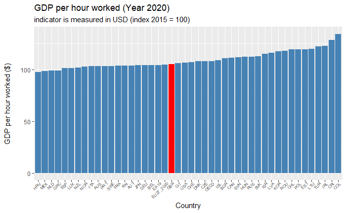

```r
gdp_phw %>%
  mutate(time = year(time)) %>%
  filter(
    # LOCATION %in% c("G-7", "EU28", "CAN", "FRA", "DEU", "ITA", "JPN", "USA", "GBR"),
    measure == "IDX2015",
    time == 2020
    ) %>%
  select(-c(indicator, frequency, measure, subject, time, flag_codes)) %>%
  ggplot() +
  aes(
    x = reorder(location, value),
    y = value,
    fill = reorder(location, value) == "GBR"
    ) +
  geom_col() +
  scale_fill_manual(values = c('steelblue', 'red'), guide = "none") +
  theme(
    axis.text.x = element_text(size = 6, angle = 45, vjust = 1.15, hjust = 1)
    ) +
  ggtitle(
    "GDP per hour worked (Year 2020)",
    subtitle =  "indicator is measured in USD (index 2015 = 100)"
  ) +
  labs(
    x = "Country",
    y = "GDP per hour worked ($)\n"
  )
```

**OECD Investment by Asset**

Read data

```r
inv_asset <- read_csv(here("raw_data/OECD_Investment_by_Asset_JHios.csv")) %>%
  clean_names()
glimpse(inv_asset)
```

```
Rows: 8,113
Columns: 8
$ location   <chr> "NZL", "NZL", "NZL", "NZL", "NZL", "NZL", "NZL", "NZL", "NZL", "NZL", "NZL", "NZL", "NZL", "NZL", "NZL", "NZL", "NZL", "NZL", "NZL", "NZ~
$ indicator  <chr> "GFCFASSET", "GFCFASSET", "GFCFASSET", "GFCFASSET", "GFCFASSET", "GFCFASSET", "GFCFASSET", "GFCFASSET", "GFCFASSET", "GFCFASSET", "GFCFA~
$ subject    <chr> "OTHMACHINEQT", "OTHMACHINEQT", "OTHMACHINEQT", "OTHMACHINEQT", "OTHMACHINEQT", "OTHMACHINEQT", "OTHMACHINEQT", "OTHMACHINEQT", "OTHMACH~
$ measure    <chr> "PC_GFCF", "PC_GFCF", "PC_GFCF", "PC_GFCF", "PC_GFCF", "PC_GFCF", "PC_GFCF", "PC_GFCF", "PC_GFCF", "PC_GFCF", "PC_GFCF", "PC_GFCF", "PC_~
$ frequency  <chr> "A", "A", "A", "A", "A", "A", "A", "A", "A", "A", "A", "A", "A", "A", "A", "A", "A", "A", "A", "A", "A", "A", "A", "A", "A", "A", "A", "~
$ time       <dbl> 1971, 1972, 1973, 1974, 1975, 1976, 1977, 1978, 1979, 1980, 1981, 1982, 1983, 1984, 1985, 1986, 1987, 1988, 1989, 1990, 1991, 1992, 1993~
$ value      <dbl> 2.3447402, 2.3421589, 2.2280472, 2.6297086, 2.7333527, 3.1940378, 4.0083835, 4.3093129, 5.0158156, 5.4235339, 6.1697723, 7.7076256, 10.0~
$ flag_codes <chr> NA, NA, NA, NA, NA, NA, NA, NA, NA, NA, NA, NA, NA, NA, NA, NA, NA, NA, NA, NA, NA, NA, NA, NA, NA, NA, NA, NA, NA, NA, NA, NA, NA, NA, ~
```

Change time in datetime format

```r
inv_asset <- inv_asset %>%
  mutate(time = make_datetime(time))
```

Check for NA’s

```r
inv_asset %>%
  summarise(across(.cols = everything(),
                   .fns = ~sum(is.na(.x))))
```

| location | indicator | subject | measure | frequency | time | value | flag_codes |
| --- | --- | --- | --- | --- | --- | --- | --- |
| 0 | 0 | 0 | 0 | 0 | 0 | 0 | 7307 |

```r
inv_asset %>%
  # distinct(LOCATION)
  # distinct(INDICATOR) # GFCFASSET
  distinct(subject) # OTHMACHINEQT, CULTASSET, OTHBUILDING, FIXASSET, TRANSPEQT, DWELLING
```

| subject |
| --- |
| OTHMACHINEQT |
| CULTASSET |
| OTHBUILDING |
| FIXASSET |
| TRANSPEQT |
| DWELLING |

```r
  # distinct(MEASURE) # PC_GFCF
  # distinct(FREQUENCY) #A
  # distinct(`Flag Codes`) # NA, E, B
```

OTHMACHINEQT: Information and Communication Technology (ICT) equipment (computer software and databases, telecommunications equipment and computer hardware)

CULTASSET: cultivated biological resources (managed forests, livestock raised for milk production, etc.)

OTHBUILDING: other buildings and structures (roads, bridges, airfields, dams, etc.)

FIXASSET: intellectual property products (such as R&D, mineral exploration, software and databases, and literary and artistic originals, etc.)

TRANSPEQT: transport equipment (ships, trains, aircraft, etc.)

DWELLING: dwellings (excluding land)

**OECD Investment GFCF**

Read data

```r
gfcf <- read_csv(here("raw_data/OECD_Investment_GFCF_JHios.csv")) %>%
  clean_names()
glimpse(gfcf)
```

```
Rows: 23,956
Columns: 8
$ location   <chr> "AUS", "AUS", "AUS", "AUS", "AUS", "AUS", "AUS", "AUS", "AUS", "AUS", "AUS", "AUS", "AUS", "AUS", "AUS", "AUS", "AUS", "AUS", "AUS", "AU~
$ indicator  <chr> "GFCF", "GFCF", "GFCF", "GFCF", "GFCF", "GFCF", "GFCF", "GFCF", "GFCF", "GFCF", "GFCF", "GFCF", "GFCF", "GFCF", "GFCF", "GFCF", "GFCF", ~
$ subject    <chr> "TOT", "TOT", "TOT", "TOT", "TOT", "TOT", "TOT", "TOT", "TOT", "TOT", "TOT", "TOT", "TOT", "TOT", "TOT", "TOT", "TOT", "TOT", "TOT", "TO~
$ measure    <chr> "AGRWTH", "AGRWTH", "AGRWTH", "AGRWTH", "AGRWTH", "AGRWTH", "AGRWTH", "AGRWTH", "AGRWTH", "AGRWTH", "AGRWTH", "AGRWTH", "AGRWTH", "AGRWT~
$ frequency  <chr> "A", "A", "A", "A", "A", "A", "A", "A", "A", "A", "A", "A", "A", "A", "A", "A", "A", "A", "A", "A", "A", "A", "A", "A", "A", "A", "A", "~
$ time       <chr> "1960", "1961", "1962", "1963", "1964", "1965", "1966", "1967", "1968", "1969", "1970", "1971", "1972", "1973", "1974", "1975", "1976", ~
$ value      <dbl> 5.671711, 1.778081, 6.252030, 9.366150, 7.483513, 8.132420, 5.097216, 7.374136, 6.391864, 3.280286, 3.221345, 2.806477, 3.058763, 4.2681~
$ flag_codes <chr> NA, NA, NA, NA, NA, NA, NA, NA, NA, NA, NA, NA, NA, NA, NA, NA, NA, NA, NA, NA, NA, NA, NA, NA, NA, NA, NA, NA, NA, NA, NA, NA, NA, NA, ~
```

Change time in datetime format

```r
gfcf <- gfcf %>%
  mutate(time = make_datetime(time))
```

Check for NA’s

```r
gfcf %>%
  summarise(across(.cols = everything(),
                   .fns = ~sum(is.na(.x))))
```

| location | indicator | subject | measure | frequency | time | value | flag_codes |
| --- | --- | --- | --- | --- | --- | --- | --- |
| 0 | 0 | 0 | 0 | 0 | 18811 | 0 | 16402 |

```r
gfcf %>%
  # distinct(LOCATION)
  # distinct(INDICATOR) # GFCF
  # distinct(SUBJECT) # TOT
  distinct(measure) # AGRWTH, MLN_USD, QGRWTH
```

| measure |
| --- |
| AGRWTH |
| MLN_USD |
| QGRWTH |

```r
  # distinct(FREQUENCY) #A, Q
  # distinct(`Flag Codes`) # NA, E, P, B, D
```

AGRWTH: Annual growth (%) MLN_USD: Million US Dollars QGRWTH: Quarterly growth rate (%)

Join investment by asset with GFCF data

```r
gfcf_light <- gfcf %>%
  filter(measure == "MLN_USD") %>%
  select(location, time, value) %>%
  rename(gfcf = value)

inv_asset_usd <- inv_asset %>%
  arrange(location, subject, time) %>%
  left_join(gfcf_light, by = c("location", "time")) %>%
  mutate(
    value_mil_usd = value * gfcf / 100
  )
```

OTHMACHINEQT: Information and Communication Technology (ICT) equipment (computer software and databases, telecommunications equipment and computer hardware)

CULTASSET: cultivated biological resources (managed forests, livestock raised for milk production, etc.)

OTHBUILDING: other buildings and structures (roads, bridges, airfields, dams, etc.)

FIXASSET: intellectual property products (such as R&D, mineral exploration, software and databases, and literary and artistic originals, etc.)

TRANSPEQT: transport equipment (ships, trains, aircraft, etc.)

DWELLING: dwellings (excluding land)

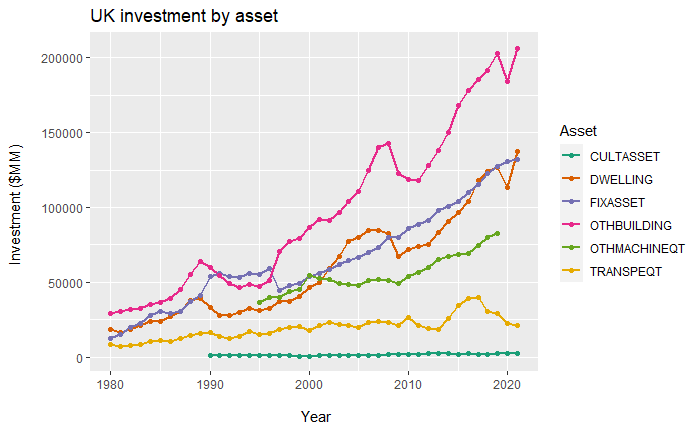

```r
inv_asset_usd %>%
  select(-c(indicator, frequency, measure, flag_codes)) %>%
  filter(location %in% c("GBR")) %>%
  ggplot() +
  aes(x = time, y = value_mil_usd, colour = subject) +
  geom_line(size = 0.75) +
  geom_point(size = 1.5) +
  scale_colour_brewer(palette = "Dark2") +
  # scale_colour_manual(values = cbb_palette) +
  ggtitle("UK investment by asset") +
  labs(
    x = "\n Year",
    y = "Investment ($MM) \n",
    colour = "Asset"
  )
```

G-7 investment by Asset (million USD)

```r
inv_asset_g7 <- inv_asset %>%
  filter(
    location %in% c("CAN", "FRA", "DEU", "ITA", "JPN", "USA", "GBR")
    ) %>%
  select(-c(indicator, frequency, measure, flag_codes)) %>%
  pivot_wider(names_from = subject, values_from = value) %>%
  rename(
    ict = OTHMACHINEQT,
    cultasset = CULTASSET,
    infrastuct = OTHBUILDING,
    intelprop = FIXASSET,
    transpeqt = TRANSPEQT,
    dwelling = DWELLING
  ) %>%
  left_join(gfcf_light, by = c("location", "time")) %>%
  mutate(
    ict_mil_usd = ict * gfcf / 100,
    cultasset_mil_usd = cultasset * gfcf / 100,
    infrastuct_mil_usd = infrastuct * gfcf / 100,
    intelprop_mil_usd = intelprop * gfcf / 100,
    transpeqt_mil_usd = transpeqt * gfcf / 100,
    dwelling_mil_usd = dwelling * gfcf / 100
  ) %>%
  select(-gfcf, -ict, -cultasset, -infrastuct, -intelprop, -transpeqt, -dwelling) %>%
  arrange(location, time)
```

OECD Education Spending Expenditure

Read data

```r
edu_exp <- read_csv(here("raw_data/OECD_Public_Spending_on_Education_JHios.csv")) %>%
  clean_names()
glimpse(edu_exp)
```

```
Rows: 1,620
Columns: 8
$ location   <chr> "AUS", "AUS", "AUS", "AUS", "AUS", "AUS", "AUS", "AUS", "AUS", "AUS", "AUS", "AUS", "AUS", "AUT", "AUT", "AUT", "AUT", "AUT", "AUT", "AU~
$ indicator  <chr> "EDUPUBEXP", "EDUPUBEXP", "EDUPUBEXP", "EDUPUBEXP", "EDUPUBEXP", "EDUPUBEXP", "EDUPUBEXP", "EDUPUBEXP", "EDUPUBEXP", "EDUPUBEXP", "EDUPU~
$ subject    <chr> "TRY", "TRY", "TRY", "TRY", "TRY", "TRY", "TRY", "TRY", "TRY", "TRY", "TRY", "TRY", "TRY", "TRY", "TRY", "TRY", "TRY", "TRY", "TRY", "TR~
$ measure    <chr> "PC_GDP", "PC_GDP", "PC_GDP", "PC_GDP", "PC_GDP", "PC_GDP", "PC_GDP", "PC_GDP", "PC_GDP", "PC_GDP", "PC_GDP", "PC_GDP", "PC_GDP", "PC_GD~
$ frequency  <chr> "A", "A", "A", "A", "A", "A", "A", "A", "A", "A", "A", "A", "A", "A", "A", "A", "A", "A", "A", "A", "A", "A", "A", "A", "A", "A", "A", "~
$ time       <dbl> 2000, 2005, 2008, 2009, 2010, 2011, 2012, 2013, 2014, 2015, 2016, 2017, 2018, 2012, 2013, 2014, 2015, 2016, 2017, 2018, 2005, 2008, 2009~
$ value      <dbl> 0.7460824, 0.6911921, 0.6902357, 0.7358844, 0.7797844, 0.7440488, 0.7194145, 0.7188712, 0.7170264, 0.7682429, 0.7551060, 0.7273703, 0.65~
$ flag_codes <lgl> NA, NA, NA, NA, NA, NA, NA, NA, NA, NA, NA, NA, NA, NA, NA, NA, NA, NA, NA, NA, NA, NA, NA, NA, NA, NA, NA, NA, NA, NA, NA, NA, NA, NA, ~
```

Change time in datetime format

```r
edu_exp <- edu_exp %>%
  mutate(time = make_datetime(time))
```

Check for NA’s

```r
edu_exp %>%
  summarise(across(.cols = everything(),
                   .fns = ~sum(is.na(.x))))
```

| location | indicator | subject | measure | frequency | time | value | flag_codes |
| --- | --- | --- | --- | --- | --- | --- | --- |
| 0 | 0 | 0 | 0 | 0 | 0 | 0 | 1620 |

G-7 countries education expenditure (% GDP) TRY : TeRtiarY PRY_NTRY: PRimarY to post-secondary Non-TeRtiarY PRY_TRY: PRimarY to TeRtiarY

View G-7 tertiary education (% GDP)

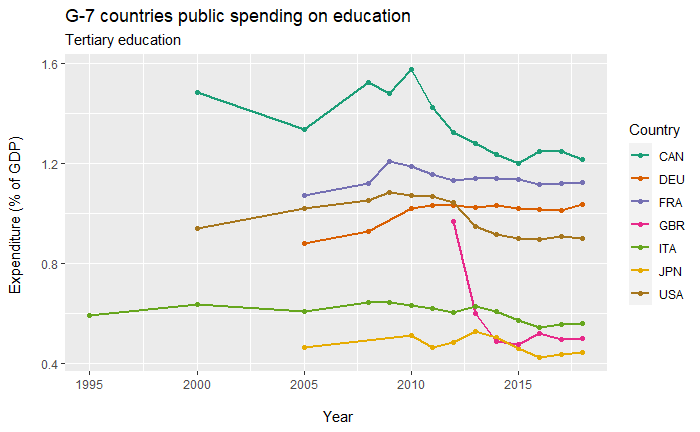

```r
edu_exp %>%
  select(-c(indicator, frequency, measure, flag_codes)) %>%
  filter(
    location %in% c("CAN", "FRA", "DEU", "ITA", "JPN", "USA", "GBR"),
    subject == "TRY"
    ) %>%
  ggplot() +
  aes(x = time, y = value, colour = location) +
  geom_line(size = 0.75) +
  geom_point(size = 1.5) +
  scale_colour_brewer(palette = "Dark2") +
  # scale_colour_manual(values = cbb_palette) +
  ggtitle(
    "G-7 countries public spending on education",
    subtitle = "Tertiary education"
  ) +
  labs(
    x = "\n Year",
    y = "Expenditure (% of GDP) \n",
    colour = "Country"
  )
```

View G-7 primary to tertiary education (% GDP)

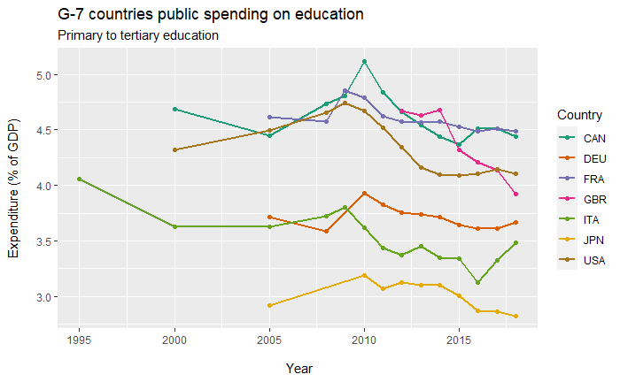

```r
edu_exp %>%
  select(-c(indicator, frequency, measure, flag_codes)) %>%
  filter(
    location %in% c("CAN", "FRA", "DEU", "ITA", "JPN", "USA", "GBR"),
    subject == "PRY_TRY"
    ) %>%
  ggplot() +
  aes(x = time, y = value, colour = location) +
  geom_line(size = 0.75) +
  geom_point(size = 1.5) +
  scale_colour_brewer(palette = "Dark2") +
  # scale_colour_manual(values = cbb_palette) +
  ggtitle(
    "G-7 countries public spending on education",
    subtitle = "Primary to tertiary education"
  ) +
  labs(
    x = "\n Year",
    y = "Expenditure (% of GDP)\n",
    colour = "Country"
  )
```

View G-7 primary to post-secondary non-tertiary education (% GDP)

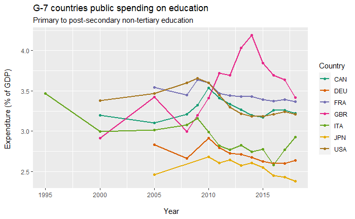

```r
edu_exp %>%
  select(-c(indicator, frequency, measure, flag_codes)) %>%
  filter(
    location %in% c("CAN", "FRA", "DEU", "ITA", "JPN", "USA", "GBR"),
    subject == "PRY_NTRY"
    ) %>%
  ggplot() +
  aes(x = time, y = value, colour = location) +
  geom_line(size = 0.75) +
  geom_point(size = 1.5) +
  scale_colour_brewer(palette = "Dark2") +
  # scale_colour_manual(values = cbb_palette) +
  ggtitle(
    "G-7 countries public spending on education",
    subtitle = "Primary to post-secondary non-tertiary education"
  ) +
  labs(
    x = "\n Year",
    y = "Expenditure (% of GDP) \n",
    colour = "Country"
  )
```

UK education expenditure (% GDP) TRY : TeRtiarY PRY_NTRY: PRimarY to post-secondary Non-TeRtiarY PRY_TRY: PRimarY to TeRtiarY

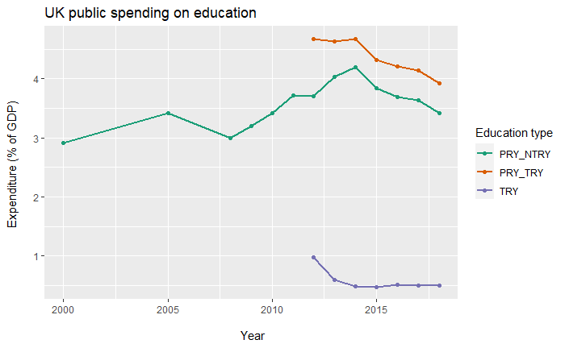

```r
edu_exp %>%
  select(-c(indicator, frequency, measure, flag_codes)) %>%
  filter(location %in% c("GBR")) %>%
  ggplot() +
  aes(x = time, y = value, colour = subject) +
  geom_line(size = 0.75) +
  geom_point(size = 1.5) +
  scale_colour_brewer(palette = "Dark2") +
  # scale_colour_manual(values = cbb_palette) +
  ggtitle("UK public spending on education") +
  labs(
    x = "\n Year",
    y = "Expenditure (% of GDP) \n",
    colour = "Education type"
  )
```

**GDP-derived expenditure in USD**

OECD_Gross_Domestic_Product_GDP

Read data

```r
gdp <- read_csv(here("raw_data/OECD_Gross_Domestic_Product_GDP_JHios.csv")) %>%
  clean_names()
glimpse(gdp)
```

```
Rows: 5,137
Columns: 8
$ location   <chr> "AUS", "AUS", "AUS", "AUS", "AUS", "AUS", "AUS", "AUS", "AUS", "AUS", "AUS", "AUS", "AUS", "AUS", "AUS", "AUS", "AUS", "AUS", "AUS", "AU~
$ indicator  <chr> "GDP", "GDP", "GDP", "GDP", "GDP", "GDP", "GDP", "GDP", "GDP", "GDP", "GDP", "GDP", "GDP", "GDP", "GDP", "GDP", "GDP", "GDP", "GDP", "GD~
$ subject    <chr> "TOT", "TOT", "TOT", "TOT", "TOT", "TOT", "TOT", "TOT", "TOT", "TOT", "TOT", "TOT", "TOT", "TOT", "TOT", "TOT", "TOT", "TOT", "TOT", "TO~
$ measure    <chr> "MLN_USD", "MLN_USD", "MLN_USD", "MLN_USD", "MLN_USD", "MLN_USD", "MLN_USD", "MLN_USD", "MLN_USD", "MLN_USD", "MLN_USD", "MLN_USD", "MLN~
$ frequency  <chr> "A", "A", "A", "A", "A", "A", "A", "A", "A", "A", "A", "A", "A", "A", "A", "A", "A", "A", "A", "A", "A", "A", "A", "A", "A", "A", "A", "~
$ time       <dbl> 1960, 1961, 1962, 1963, 1964, 1965, 1966, 1967, 1968, 1969, 1970, 1971, 1972, 1973, 1974, 1975, 1976, 1977, 1978, 1979, 1980, 1981, 1982~
$ value      <dbl> 25073.26, 25364.88, 27955.36, 30432.98, 32745.29, 34542.34, 38344.55, 41068.68, 46560.93, 52215.40, 58858.35, 64135.62, 69807.50, 78843.~
$ flag_codes <chr> NA, NA, NA, NA, NA, NA, NA, NA, NA, NA, NA, NA, NA, NA, NA, NA, NA, NA, NA, NA, NA, NA, NA, NA, NA, NA, NA, NA, NA, NA, NA, NA, NA, NA, ~
```

Change time in datetime format

```r
gdp <- gdp %>%
  mutate(time = make_datetime(time))
```

Check for NA’s

```r
gdp %>%
  summarise(across(.cols = everything(),
                   .fns = ~sum(is.na(.x))))
```

| location | indicator | subject | measure | frequency | time | value | flag_codes |
| --- | --- | --- | --- | --- | --- | --- | --- |
| 0 | 0 | 0 | 0 | 0 | 0 | 0 | 3824 |

```r
gdp %>%
  # distinct(LOCATION)
  distinct(indicator) # GDP
```

| indicator |
| --- |
| GDP |

```r
  # distinct(SUBJECT) # TOT
  # distinct(MEASURE) # MLN_USD, USD_CAP
  # distinct(FREQUENCY) #A
  # distinct(`Flag Codes`) # NA, E, P, B, D
```

View data

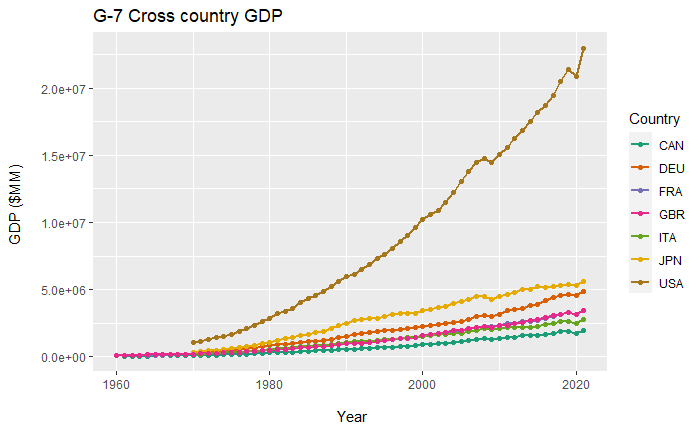

```r
gdp %>%
  select(-c(indicator, subject, frequency, flag_codes)) %>%
  filter(
    location %in% c("CAN", "FRA", "DEU", "ITA", "JPN", "USA", "GBR"),
    measure == "MLN_USD"
    ) %>%
  ggplot() +
  aes(x = time, y = value, group = location, color = location) +
  geom_line(size = 0.75) +
  geom_point(size = 1.5) +
  scale_colour_brewer(palette = "Dark2") +
  ggtitle("G-7 Cross country GDP") +
  labs(
    x = "\n Year",
    y = "GDP ($MM) \n",
    colour = "Country"
  )
```

Join education expenditure with GDP data

```r
gdp_light <- gdp %>%
  filter(measure == "MLN_USD") %>%
  select(location, time, value) %>%
  rename(gdp = value)


edu_exp_usd <- edu_exp %>%
  left_join(gdp_light, by = c("location", "time")) %>%
  mutate(
    value_mil_usd = value * gdp / 100
  )
```

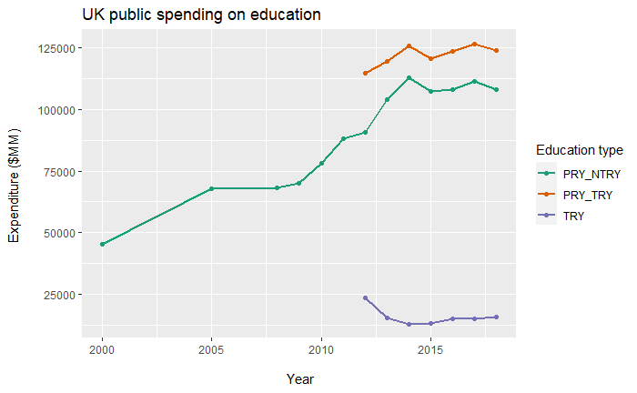

```r
edu_exp_usd %>%
  select(-c(indicator, frequency, measure, flag_codes)) %>%
  filter(location %in% c("GBR")) %>%
  ggplot() +
  aes(x = time, y = value_mil_usd, colour = subject) +
  geom_line(size = 0.75) +
  geom_point(size = 1.5) +
  scale_colour_brewer(palette = "Dark2") +
  # scale_colour_manual(values = cbb_palette) +
  ggtitle("UK public spending on education") +
  labs(
    x = "\n Year",
    y = "Expenditure ($MM) \n",
    colour = "Education type"
  )
```

G-7 expenditure on education

```r
edu_exp_g7 <- edu_exp %>%
  filter(
    location %in% c("CAN", "FRA", "DEU", "ITA", "JPN", "USA", "GBR")
    ) %>%
  select(-c(indicator, frequency, measure, flag_codes)) %>%
  pivot_wider(names_from = subject, values_from = value) %>%
  rename(
    try_pc_gdp = TRY,
    pry_ntry_pc_gdp = PRY_NTRY,
    pry_try_pc_gdp = PRY_TRY
  ) %>%
  left_join(gdp_light, by = c("location", "time"))%>%
  mutate(
    try_mil_usd = try_pc_gdp * gdp / 100,
    pry_ntry_mil_usd = pry_ntry_pc_gdp * gdp / 100,
    pry_try_mil_usd = pry_try_pc_gdp * gdp / 100
  ) %>%
  select(-try_pc_gdp, -pry_ntry_pc_gdp, -pry_try_pc_gdp, -gdp)%>%
  arrange(location, time)
```

**Compare productivity by industry in UK and EU Countries**

Load Data

```r
productivity_phw <- read_excel(here("raw_data/International_Labour_Productivity-Europe.xls"), sheet = "Table 1 R-proc")
productivity_growth <- read_excel(here("raw_data/International_Labour_Productivity-Europe.xls"), sheet = "Table 2 R-proc")


glimpse(productivity_phw)
```

```
Rows: 9
Columns: 31
$ `A*10 (excl L)`  <chr> "A", "B-E", "F", "G-I", "J", "K", "M-N", "O-Q", "R-U"
$ `NACE Industry`  <chr> "Agriculture, forestry and fishing", "Industry (except construction)", "Construction", "Wholesale and retail trade, transport, acco~
$ Belgium          <dbl> 25.66616, 60.19409, 38.87564, 41.93782, 59.65125, 88.10338, 24.53516, 28.17312, 19.69698
$ Bulgaria         <dbl> 2.600904, 12.304376, 9.656289, 8.787120, 29.345819, 63.410313, 14.696489, 20.903489, 18.492694
$ `Czech Republic` <dbl> 14.05971, 23.72004, 13.17658, 15.50173, 40.03371, 59.11678, 19.91482, 25.96555, 17.04386
$ Denmark          <dbl> 31.74844, 68.35846, 24.29677, 34.50571, 46.87635, 72.01052, 26.97661, 24.77941, 22.36061
$ Germany          <dbl> 19.49727, 52.43710, 20.68757, 29.74980, 60.08252, 51.46037, 31.99290, 27.90071, 22.09946
$ Estonia          <dbl> 16.88883, 17.08604, 13.67928, 14.98199, 31.06519, 57.22183, 24.90567, 15.93756, 10.01729
$ Ireland          <dbl> 9.591133, 72.697607, 25.150283, 25.012769, 100.300137, 62.397006, 36.499863, 22.530640, 17.449500
$ Greece           <dbl> 5.210345, 27.074545, 15.911999, 13.549916, 27.128820, 49.926840, 12.507425, 25.603642, 12.489497
$ Spain            <dbl> 19.88720, 44.38977, 34.85822, 23.12436, 43.96195, 55.78498, 19.17254, 24.39174, 14.69544
$ France           <dbl> 18.03665, 47.50529, 24.92221, 32.25440, 62.20943, 53.23991, 31.13475, 29.20290, 18.40162
$ Croatia          <dbl> 6.929569, 14.181170, 14.690133, 11.301189, 27.066587, 56.951325, 26.218405, 15.802399, 17.817717
```

[output cut: 18 more lines]

```r
glimpse(productivity_growth)
```

```
Rows: 9
Columns: 29
$ `A*10 (excl L)`  <chr> "A", "B-E", "F", "G-I", "J", "K", "M-N", "O-Q", "R-U"
$ `NACE Industry`  <chr> "Agriculture, forestry and fishing", "Industry (except construction)", "Construction", "Wholesale and retail trade, transport, acco~
$ Bulgaria         <dbl> 0.03762024, 0.04306486, 0.01968665, 0.07392434, -0.08274970, -0.02440974, 0.04568291, 0.01949288, -0.02800381
$ `Czech Republic` <dbl> 0.15523012, 0.04230038, 0.03184858, 0.04930588, 0.07100998, 0.17305095, 0.04829006, 0.00411687, 0.01648911
$ Denmark          <dbl> 0.09561540, 0.01081644, 0.01146514, -0.02340411, 0.11628837, -0.10960605, 0.01762140, 0.01010562, 0.01446469
$ Germany          <dbl> 0.207427124, 0.041322490, 0.019115609, 0.021288599, 0.025971707, 0.029641791, -0.003529125, 0.005855962, 0.015685401
$ Estonia          <dbl> -0.21282514, -0.03410064, 0.03195887, 0.01055122, -0.08222485, -0.21902659, 0.02644456, 0.05304766, -0.05042502
$ Ireland          <dbl> 0.149116937, 0.753785373, 0.009196466, 0.071386415, 0.168403154, 0.114763465, 0.316017336, 0.027947060, -0.002288232
$ Greece           <dbl> -0.0363313989, 0.0009277398, -0.0067258433, -0.0498922663, -0.0958815588, 0.0005509581, -0.0752025048, -0.0365579797, 0.0425457757
$ Spain            <dbl> 0.007651545, 0.028572102, -0.047825854, 0.026538370, -0.023294791, -0.055613456, 0.034704412, 0.013199765, -0.010159202
$ France           <dbl> -0.073544029, 0.045800398, 0.018924530, 0.027709269, 0.031334875, -0.025443408, -0.015632316, 0.009189933, 0.023611436
$ Croatia          <dbl> 0.22078574, 0.11458163, -0.04157474, 0.17401630, -0.16943833, -0.01810939, -0.16417076, 0.08328010, -0.17354945
$ Italy            <dbl> 0.013393880, 0.012490617, 0.021676441, -0.004523443, -0.002343728, -0.034086473, -0.029787546, -0.024783609, -0.009893064
```

[output cut: 16 more lines]

Check for NA values

```r
productivity_phw %>%
  summarise(across(.cols = everything(),
                   .fns = ~sum(is.na(.x))))
```

| A*10 (excl L) | NACE Industry | Belgium | Bulgaria | Czech Republic | Denmark | Germany | Estonia | Ireland | Greece | Spain | France | Croatia | Italy | Cyprus | Latvia | Lithuania | Luxembourg | Hungary | Netherlands | Austria | Poland | Portugal | Romania | Slovenia | Slovakia | Finland | Sweden | United Kingdom | Norway | … |
| --- | --- | --- | --- | --- | --- | --- | --- | --- | --- | --- | --- | --- | --- | --- | --- | --- | --- | --- | --- | --- | --- | --- | --- | --- | --- | --- | --- | --- | --- | --- |
| 0 | 0 | 0 | 0 | 0 | 0 | 0 | 0 | 0 | 0 | 0 | 0 | 0 | 0 | 0 | 0 | 0 | 0 | 0 | 0 | 0 | 0 | 0 | 0 | 0 | 0 | 0 | 0 | 0 | 0 | … |

```r
productivity_growth %>%
  summarise(across(.cols = everything(),
                   .fns = ~sum(is.na(.x))))
```

| A*10 (excl L) | NACE Industry | Bulgaria | Czech Republic | Denmark | Germany | Estonia | Ireland | Greece | Spain | France | Croatia | Italy | Cyprus | Latvia | Lithuania | Luxembourg | Hungary | Netherlands | Austria | Poland | Portugal | Romania | Slovenia | Slovakia | Finland | Sweden | United Kingdom | Norway |
| --- | --- | --- | --- | --- | --- | --- | --- | --- | --- | --- | --- | --- | --- | --- | --- | --- | --- | --- | --- | --- | --- | --- | --- | --- | --- | --- | --- | --- |
| 0 | 0 | 0 | 0 | 0 | 0 | 0 | 0 | 0 | 0 | 0 | 0 | 0 | 0 | 0 | 0 | 0 | 0 | 0 | 0 | 0 | 0 | 0 | 0 | 0 | 0 | 0 | 0 | 0 |

Pivot data to long format

```r
tidy_productivity_phw <- productivity_phw %>%
  pivot_longer(-c(`A*10 (excl L)`, `NACE Industry`), names_to = "Country", values_to = "Output_per_hour")

tidy_productivity_growth <- productivity_growth %>%
  pivot_longer(-c(`A*10 (excl L)`, `NACE Industry`), names_to = "Country", values_to = "Labour_Productivity_Growth")


tidy_productivity_phw
```

| A*10 (excl L) | NACE Industry | Country | Output_per_hour |
| --- | --- | --- | --- |
| A | Agriculture, forestry and fishing | Belgium | 25.666164 |
| A | Agriculture, forestry and fishing | Bulgaria | 2.600904 |
| A | Agriculture, forestry and fishing | Czech Republic | 14.059709 |
| A | Agriculture, forestry and fishing | Denmark | 31.748444 |
| A | Agriculture, forestry and fishing | Germany | 19.497269 |
| A | Agriculture, forestry and fishing | Estonia | 16.888828 |
| A | Agriculture, forestry and fishing | Ireland | 9.591133 |
| A | Agriculture, forestry and fishing | Greece | 5.210345 |
| A | Agriculture, forestry and fishing | Spain | 19.887198 |
| A | Agriculture, forestry and fishing | France | 18.036654 |

[output cut: 251 more lines]

```r
tidy_productivity_growth
```

| A*10 (excl L) | NACE Industry | Country | Labour_Productivity_Growth |
| --- | --- | --- | --- |
| A | Agriculture, forestry and fishing | Bulgaria | 3.762024e-02 |
| A | Agriculture, forestry and fishing | Czech Republic | 1.552301e-01 |
| A | Agriculture, forestry and fishing | Denmark | 9.561540e-02 |
| A | Agriculture, forestry and fishing | Germany | 2.074271e-01 |
| A | Agriculture, forestry and fishing | Estonia | -2.128251e-01 |
| A | Agriculture, forestry and fishing | Ireland | 1.491169e-01 |
| A | Agriculture, forestry and fishing | Greece | -3.633140e-02 |
| A | Agriculture, forestry and fishing | Spain | 7.651545e-03 |
| A | Agriculture, forestry and fishing | France | -7.354403e-02 |
| A | Agriculture, forestry and fishing | Croatia | 2.207857e-01 |

[output cut: 233 more lines]

Comparison of large economies in Europe: UK, France, Germany

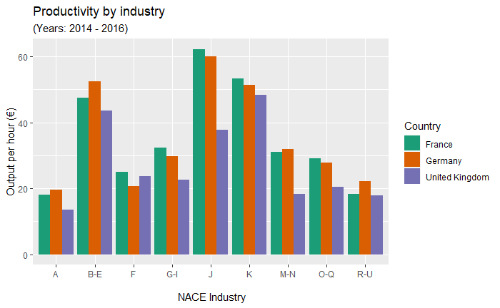

```r
tidy_productivity_phw %>%
  filter(
    Country %in% c("United Kingdom", "France", "Germany")
  ) %>%
  ggplot() +
  aes(
    x = `A*10 (excl L)`,
    y = Output_per_hour,
    fill = Country
    ) +
  geom_col(position = "dodge") +
  scale_fill_brewer(palette = "Dark2") +
  ggtitle(
    "Productivity by industry",
    subtitle =  "(Years: 2014 - 2016)"
  ) +
  labs(
    x = "\n NACE Industry",
    y = "Output per hour (€)"
  )
```

```r
tidy_productivity_phw %>%
  distinct(`A*10 (excl L)`, `NACE Industry`)
```

| A*10 (excl L) | NACE Industry |
| --- | --- |
| A | Agriculture, forestry and fishing |
| B-E | Industry (except construction) |
| F | Construction |
| G-I | Wholesale and retail trade, transport, accommodation and food service activities |
| J | Information and communication |
| K | Financial and insurance activities |
| M-N | Professional, scientific and technical activities; administrative and support service activities |
| O-Q | Public administration, defence, education, human health and social work activities |
| R-U | Arts, entertainment and recreation; other service activities |

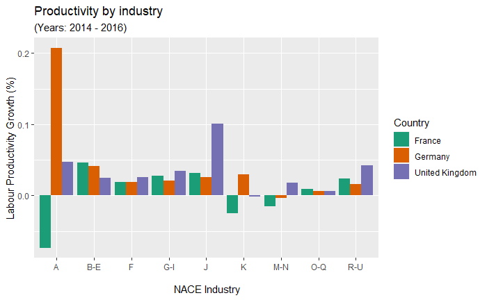

```r
tidy_productivity_growth %>%
  filter(
    Country %in% c("United Kingdom", "France", "Germany")
  ) %>%
  ggplot() +
  aes(
    x = `A*10 (excl L)`,
    y = Labour_Productivity_Growth,
    fill = Country
    ) +
  geom_col(position = "dodge") +
  scale_fill_brewer(palette = "Dark2") +
  ggtitle(
    "Productivity by industry",
    subtitle =  "(Years: 2014 - 2016)"
  ) +
  labs(
    x = "\n NACE Industry",
    y = "Labour Productivity Growth (%)"
  )
```

**Data for modelling**

```r
productivity <- gdp_phw_g7 %>%
  left_join(edu_exp_g7, by = c("location", "time")) %>%
  left_join(inv_asset_g7, by = c("location", "time"))

glimpse(productivity)
```

```
Rows: 360
Columns: 12
$ location           <chr> "CAN", "CAN", "CAN", "CAN", "CAN", "CAN", "CAN", "CAN", "CAN", "CAN", "CAN", "CAN", "CAN", "CAN", "CAN", "CAN", "CAN", "CAN", "C~
$ time               <dttm> 1970-01-01, 1971-01-01, 1972-01-01, 1973-01-01, 1974-01-01, 1975-01-01, 1976-01-01, 1977-01-01, 1978-01-01, 1979-01-01, 1980-01~
$ gdp_phw_usd        <dbl> 28.62992, 29.33436, 30.35025, 31.07351, 31.07195, 31.42778, 33.28053, 34.20403, 34.45608, 34.11693, 34.01649, 34.48396, 34.95985~
$ try_mil_usd        <dbl> NA, NA, NA, NA, NA, NA, NA, NA, NA, NA, NA, NA, NA, NA, NA, NA, NA, NA, NA, NA, NA, NA, NA, NA, NA, NA, NA, NA, NA, NA, 13382.88~
$ pry_ntry_mil_usd   <dbl> NA, NA, NA, NA, NA, NA, NA, NA, NA, NA, NA, NA, NA, NA, NA, NA, NA, NA, NA, NA, NA, NA, NA, NA, NA, NA, NA, NA, NA, NA, 28811.13~
$ pry_try_mil_usd    <dbl> NA, NA, NA, NA, NA, NA, NA, NA, NA, NA, NA, NA, NA, NA, NA, NA, NA, NA, NA, NA, NA, NA, NA, NA, NA, NA, NA, NA, NA, NA, 42194.02~
$ ict_mil_usd        <dbl> NA, NA, NA, NA, NA, NA, 2642.131, 2758.330, 3050.458, 3438.862, 4150.366, 5697.235, 5616.704, 6061.705, 6642.579, 7616.316, 8044~
$ cultasset_mil_usd  <dbl> NA, NA, NA, NA, NA, NA, NA, NA, NA, NA, NA, NA, NA, NA, NA, NA, NA, NA, NA, NA, NA, NA, NA, NA, NA, NA, NA, NA, NA, NA, NA, NA, ~
$ infrastuct_mil_usd <dbl> 8870.039, 10039.748, 10300.079, 11278.354, 13374.034, 16161.353, 15926.709, 17483.943, 18867.548, 21855.263, 26077.734, 30829.96~
$ intelprop_mil_usd  <dbl> 1365.360, 1517.127, 1578.875, 1637.687, 1769.458, 2034.349, 2609.275, 2999.763, 3437.905, 3984.102, 4921.618, 5684.890, 6144.829~
$ transpeqt_mil_usd  <dbl> NA, NA, NA, NA, NA, NA, NA, NA, NA, NA, NA, 4158.514, 3149.827, 3769.343, 4845.802, 5469.769, 5658.060, 6602.742, 7291.689, 7207~
$ dwelling_mil_usd   <dbl> 4982.125, 6168.938, 7262.403, 8810.676, 9991.444, 10457.235, 13265.412, 13919.626, 14895.768, 15736.757, 16110.102, 19000.776, 1~
```

Trim UK data

```r
prod_uk_trim <- productivity %>%
  mutate(time = year(time)) %>%
  filter(
    location == "GBR",
    time >= 1995 & time <=2019
  ) %>%
  select(
    gdp_phw_usd,
    ict_mil_usd,
    cultasset_mil_usd,
    infrastuct_mil_usd,
    intelprop_mil_usd,
    transpeqt_mil_usd,
    dwelling_mil_usd
  ) %>%
  mutate(
    ict_bil_usd = ict_mil_usd / 1000,
    cultasset_bil_usd = cultasset_mil_usd / 1000,
    infrastuct_bil_usd = infrastuct_mil_usd / 1000,
    intelprop_bil_usd = intelprop_mil_usd / 1000,
    transpeqt_bil_usd = transpeqt_mil_usd / 1000,
    dwelling_bil_usd = dwelling_mil_usd / 1000
  ) %>%
  select(
    -ict_mil_usd,
    -cultasset_mil_usd,
    -infrastuct_mil_usd,
    -intelprop_mil_usd,
    -transpeqt_mil_usd,
    -dwelling_mil_usd
  )
```

Check for aliases

```r
alias(lm(gdp_phw_usd ~ ., data = prod_uk_trim))
```

```
Model :
gdp_phw_usd ~ ict_bil_usd + cultasset_bil_usd + infrastuct_bil_usd +
    intelprop_bil_usd + transpeqt_bil_usd + dwelling_bil_usd
```

Call libraries for linear regression modelling

```r
library(GGally)
library(ggfortify)
library(modelr)
```

Check for correlations in data

[output not shown]

[output cut: 17 more lines]

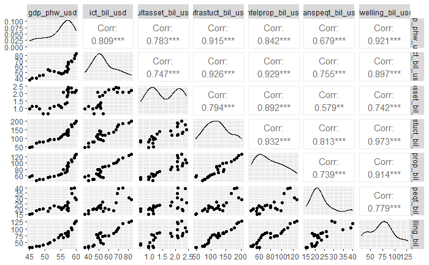

```r
ggpairs(prod_uk_trim)
```

**Automated modelling**

```r
library(glmulti)
glmulti_fit <- glmulti(
  gdp_phw_usd ~ .,
  data = prod_uk_trim,
  level = 2, # 2 = include pairwise interactions, 1 = main effects only (main effect = no pairwise interactions)
  minsize = 0, # no min size of model
  maxsize = 6, # -1 = no max size of model
  marginality = TRUE, # marginality here means the same as 'strongly hierarchical' interactions, i.e. include pairwise interactions only if both predictors present in the model as main effects.
  method = "g", # the problem is too large for exhaustive search, so search using a genetic algorithm
  crit = bic, # criteria for model selection is BIC value (lower is better)
  plotty = FALSE, # don't plot models as function runs
  report = TRUE, # do produce reports as function runs
  confsetsize = 100, # return best 100 solutions
  fitfunction = lm # fit using the `lm` function
)
```

```
Initialization...
TASK: Genetic algorithm in the candidate set.
Initialization...
Algorithm started...

After 10 generations:
Best model: gdp_phw_usd~1+cultasset_bil_usd+infrastuct_bil_usd+intelprop_bil_usd+dwelling_bil_usd+dwelling_bil_usd:cultasset_bil_usd+dwelling_bil_usd:infrastuct_bil_usd
Crit= 55.6768031771476
Mean crit= 84.4859235294878
Change in best IC: -9944.32319682285 / Change in mean IC: -9915.51407647051

After 20 generations:
Best model: gdp_phw_usd~1+cultasset_bil_usd+infrastuct_bil_usd+intelprop_bil_usd+dwelling_bil_usd+infrastuct_bil_usd:cultasset_bil_usd+dwelling_bil_usd:infrastuct_bil_usd
Crit= 49.3307496150759
Mean crit= 79.5298115235737
Change in best IC: -6.34605356207172 / Change in mean IC: -4.95611200591405

After 30 generations:
Best model: gdp_phw_usd~1+cultasset_bil_usd+infrastuct_bil_usd+intelprop_bil_usd+dwelling_bil_usd+infrastuct_bil_usd:cultasset_bil_usd+dwelling_bil_usd:infrastuct_bil_usd
Crit= 49.3307496150759
Mean crit= 75.801603572355
Change in best IC: 0 / Change in mean IC: -3.72820795121874

After 40 generations:
Best model: gdp_phw_usd~1+cultasset_bil_usd+infrastuct_bil_usd+intelprop_bil_usd+dwelling_bil_usd+infrastuct_bil_usd:cultasset_bil_usd+dwelling_bil_usd:infrastuct_bil_usd
Crit= 49.3307496150759
Mean crit= 73.9657672508814
Change in best IC: 0 / Change in mean IC: -1.83583632147361

After 50 generations:
Best model: gdp_phw_usd~1+cultasset_bil_usd+infrastuct_bil_usd+intelprop_bil_usd+dwelling_bil_usd+infrastuct_bil_usd:cultasset_bil_usd+dwelling_bil_usd:infrastuct_bil_usd
Crit= 49.3307496150759
Mean crit= 73.0762279926173
Change in best IC: 0 / Change in mean IC: -0.889539258264023

After 60 generations:
Best model: gdp_phw_usd~1+cultasset_bil_usd+infrastuct_bil_usd+intelprop_bil_usd+dwelling_bil_usd+infrastuct_bil_usd:cultasset_bil_usd+dwelling_bil_usd:infrastuct_bil_usd
Crit= 49.3307496150759
Mean crit= 73.0667986943176
Change in best IC: 0 / Change in mean IC: -0.00942929829970751
```

[output cut: 209 more lines]

[output not shown]

Summary of glmulti results

```r
summary(glmulti_fit)
```

```
$name
[1] "glmulti.analysis"

$method
[1] "g"

$fitting
[1] "lm"

$crit
[1] "bic"

$level
[1] 2

$marginality
[1] TRUE

$confsetsize
[1] 100

$bestic
[1] 49.33075

$icvalues
  [1] 49.33075 55.67680 56.20468 56.55964 57.02945 57.10769 58.16478 58.37766 58.58979 58.70080 58.76433 58.82784 59.35794 59.41643 59.73672 59.80486
 [17] 59.91400 60.01813 60.23926 60.87584 61.21856 61.52268 61.67393 61.69714 61.97470 62.19404 62.52478 62.58987 62.76328 62.77122 62.83302 62.92747
 [33] 63.00538 63.06098 63.18221 63.26074 63.27490 63.30843 63.55029 63.61374 63.80878 63.95171 64.49865 65.00164 65.26918 65.28582 65.41296 65.44166
 [49] 65.62047 65.78757 65.78882 65.91789 66.13587 66.17188 66.55359 67.14101 67.42008 67.45456 67.51034 67.68118 67.76719 67.88647 67.96365 67.99490
 [65] 68.00286 68.02477 68.04365 68.07921 68.31758 68.34297 68.37827 68.40555 68.46458 68.54663 68.63295 68.91153 68.92463 68.99457 69.45364 69.65318
 [81] 69.69883 69.89848 69.96745 70.05665 70.15690 70.33763 70.34419 70.35606 70.42668 70.45125 70.48991 70.61996 70.68308 70.84462 70.86078 70.93826
 [97] 70.94402 70.96893 70.99399 71.00882

$bestmodel
[1] "gdp_phw_usd ~ 1 + cultasset_bil_usd + infrastuct_bil_usd + intelprop_bil_usd + "
[2] "    dwelling_bil_usd + infrastuct_bil_usd:cultasset_bil_usd + "
[3] "    dwelling_bil_usd:infrastuct_bil_usd"

$modelweights
  [1] 7.821081e-01 3.275207e-02 2.515422e-02 2.106362e-02 1.665384e-02 1.601499e-02 9.440211e-03 8.487004e-03 7.632946e-03 7.220809e-03 6.995038e-03
 [12] 6.776428e-03 5.198646e-03 5.048823e-03 4.301696e-03 4.157605e-03 3.936794e-03 3.737076e-03 3.345900e-03 2.433790e-03 2.050505e-03 1.761258e-03
 [23] 1.632977e-03 1.614134e-03 1.404971e-03 1.259038e-03 1.067133e-03 1.032964e-03 9.471737e-04 9.434233e-04 9.147173e-04 8.725202e-04 8.391873e-04
 [34] 8.161800e-04 7.681752e-04 7.385987e-04 7.333866e-04 7.211940e-04 6.390480e-04 6.190909e-04 5.615675e-04 5.228355e-04 3.977395e-04 3.092974e-04
 [45] 2.705705e-04 2.683289e-04 2.518024e-04 2.482140e-04 2.269859e-04 2.087918e-04 2.086613e-04 1.956208e-04 1.754210e-04 1.722905e-04 1.423557e-04
 [56] 1.061251e-04 9.230345e-05 9.072571e-05 8.823065e-05 8.100680e-05 7.759690e-05 7.310452e-05 7.033693e-05 6.924659e-05 6.897145e-05 6.822018e-05
 [67] 6.757920e-05 6.638809e-05 5.892891e-05 5.818575e-05 5.716768e-05 5.639305e-05 5.475307e-05 5.255233e-05 5.033247e-05 4.378785e-05 4.350203e-05
 [78] 4.200710e-05 3.339160e-05 3.022081e-05 2.953892e-05 2.673255e-05 2.582636e-05 2.469981e-05 2.349226e-05 2.146246e-05 2.139224e-05 2.126561e-05
 [89] 2.052784e-05 2.027717e-05 1.988900e-05 1.863686e-05 1.805793e-05 1.665674e-05 1.652269e-05 1.589480e-05 1.584911e-05 1.565290e-05 1.545803e-05
[100] 1.534381e-05

$generations
[1] 430

$elapsed
[1] 0.02108586

$includeobjects
[1] TRUE
```

```r
# here is the best model (lowest BIC) from the glmulti run above
glmulti_fit@objects[1]
```

```
[[1]]

Call:
fitfunc(formula = as.formula(x), data = data)

Coefficients:
                         (Intercept)                     cultasset_bil_usd                    infrastuct_bil_usd                     intelprop_bil_usd
                           25.370831                              2.671541                              0.189267                              0.112780
                    dwelling_bil_usd  cultasset_bil_usd:infrastuct_bil_usd   infrastuct_bil_usd:dwelling_bil_usd
                            0.173074                             -0.036716                             -0.001181
```

```r
# if you want to see the other models
weightable(glmulti_fit)
```

| model | bic | weights |
| --- | --- | --- |
| gdp_phw_usd ~ 1 + cultasset_bil_usd + infrastuct_bil_usd + intelprop_bil_usd + dwelling_bil_usd + infrastuct_bil_usd:cultasset_bil_usd + dwelling_bil_usd:infrastuct_bil_usd | 49.33075 | 7.821081e-01 |
| gdp_phw_usd ~ 1 + cultasset_bil_usd + infrastuct_bil_usd + intelprop_bil_usd + dwelling_bil_usd + dwelling_bil_usd:cultasset_bil_usd + dwelling_bil_usd:infrastuct_bil_usd | 55.67680 | 3.275207e-02 |
| gdp_phw_usd ~ 1 + cultasset_bil_usd + infrastuct_bil_usd + intelprop_bil_usd + dwelling_bil_usd + dwelling_bil_usd:infrastuct_bil_usd | 56.20468 | 2.515422e-02 |
| gdp_phw_usd ~ 1 + cultasset_bil_usd + infrastuct_bil_usd + intelprop_bil_usd + dwelling_bil_usd + intelprop_bil_usd:cultasset_bil_usd + dwelling_bil_usd:infrastuct_bil_usd | 56.55964 | 2.106362e-02 |
| gdp_phw_usd ~ 1 + infrastuct_bil_usd + intelprop_bil_usd + dwelling_bil_usd + dwelling_bil_usd:infrastuct_bil_usd | 57.02945 | 1.665384e-02 |
| gdp_phw_usd ~ 1 + infrastuct_bil_usd + intelprop_bil_usd + transpeqt_bil_usd + dwelling_bil_usd + transpeqt_bil_usd:infrastuct_bil_usd + dwelling_bil_usd:infrastuct_bil_usd | 57.10769 | 1.601499e-02 |
| gdp_phw_usd ~ 1 + cultasset_bil_usd + infrastuct_bil_usd + intelprop_bil_usd + dwelling_bil_usd + dwelling_bil_usd:infrastuct_bil_usd + dwelling_bil_usd:intelprop_bil_usd | 58.16478 | 9.440211e-03 |
| gdp_phw_usd ~ 1 + ict_bil_usd + cultasset_bil_usd + infrastuct_bil_usd + dwelling_bil_usd + cultasset_bil_usd:ict_bil_usd + dwelling_bil_usd:infrastuct_bil_usd | 58.37766 | 8.487004e-03 |
| gdp_phw_usd ~ 1 + ict_bil_usd + intelprop_bil_usd + transpeqt_bil_usd + dwelling_bil_usd + transpeqt_bil_usd:ict_bil_usd + dwelling_bil_usd:ict_bil_usd | 58.58979 | 7.632946e-03 |
| gdp_phw_usd ~ 1 + cultasset_bil_usd + infrastuct_bil_usd + intelprop_bil_usd + transpeqt_bil_usd + dwelling_bil_usd + dwelling_bil_usd:infrastuct_bil_usd | 58.70080 | 7.220809e-03 |

[output cut: 90 more lines]

```r
# View summary of the best model (lowest BIC) from the glmulti run above
mod_auto1 <- lm(gdp_phw_usd ~ 1 + cultasset_bil_usd + infrastuct_bil_usd +
                 intelprop_bil_usd + dwelling_bil_usd +
                 infrastuct_bil_usd:cultasset_bil_usd +
                 dwelling_bil_usd:infrastuct_bil_usd,
                   data = prod_uk_trim)

summary(mod_auto1)
```

```
Call:
lm(formula = gdp_phw_usd ~ 1 + cultasset_bil_usd + infrastuct_bil_usd +
    intelprop_bil_usd + dwelling_bil_usd + infrastuct_bil_usd:cultasset_bil_usd +
    dwelling_bil_usd:infrastuct_bil_usd, data = prod_uk_trim)

Residuals:
     Min       1Q   Median       3Q      Max
-0.59966 -0.29484 -0.05087  0.21457  0.85219

Coefficients:
                                       Estimate Std. Error t value Pr(>|t|)
(Intercept)                          25.3708305  1.7350410  14.623 1.97e-11 ***
cultasset_bil_usd                     2.6715409  1.4146624   1.888 0.075189 .
infrastuct_bil_usd                    0.1892674  0.0208051   9.097 3.75e-08 ***
intelprop_bil_usd                     0.1127803  0.0241826   4.664 0.000193 ***
dwelling_bil_usd                      0.1730740  0.0281927   6.139 8.49e-06 ***
cultasset_bil_usd:infrastuct_bil_usd -0.0367162  0.0122710  -2.992 0.007818 **
infrastuct_bil_usd:dwelling_bil_usd  -0.0011812  0.0001587  -7.441 6.77e-07 ***
---
Signif. codes:  0 ‘***’ 0.001 ‘**’ 0.01 ‘*’ 0.05 ‘.’ 0.1 ‘ ’ 1

Residual standard error: 0.457 on 18 degrees of freedom
Multiple R-squared:  0.9921,    Adjusted R-squared:  0.9895
F-statistic: 378.9 on 6 and 18 DF,  p-value: < 2.2e-16
```

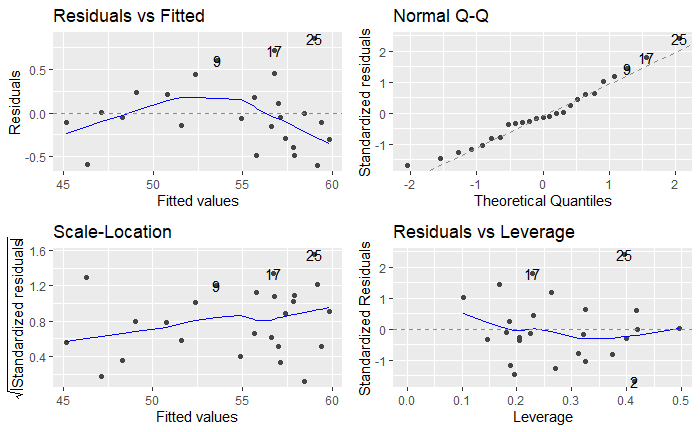

```r
# let's see diagnostic plots
autoplot(mod_auto1)
```

The diagnostic plots don’t look that great, and the `cultasset_bil_usd` coefficient is not statistically significant

Let’s check what the other models calculated by the gmulti algorithm are like

```r
# View summary of the best model (lowest BIC) from the glmulti run above
mod_auto2 <- lm(gdp_phw_usd ~ 1 + infrastuct_bil_usd + intelprop_bil_usd +
                dwelling_bil_usd + dwelling_bil_usd:infrastuct_bil_usd,
                   data = prod_uk_trim)

summary(mod_auto2)
```

```
Call:
lm(formula = gdp_phw_usd ~ 1 + infrastuct_bil_usd + intelprop_bil_usd +
    dwelling_bil_usd + dwelling_bil_usd:infrastuct_bil_usd, data = prod_uk_trim)

Residuals:
     Min       1Q   Median       3Q      Max
-1.14684 -0.35696 -0.01917  0.25889  1.02190

Coefficients:
                                      Estimate Std. Error t value Pr(>|t|)
(Intercept)                          3.108e+01  9.962e-01  31.197  < 2e-16 ***
infrastuct_bil_usd                   1.261e-01  1.452e-02   8.685 3.20e-08 ***
intelprop_bil_usd                    4.979e-02  1.420e-02   3.506  0.00222 **
dwelling_bil_usd                     2.404e-01  2.126e-02  11.306 3.86e-10 ***
infrastuct_bil_usd:dwelling_bil_usd -1.338e-03  9.823e-05 -13.626 1.40e-11 ***
---
Signif. codes:  0 ‘***’ 0.001 ‘**’ 0.01 ‘*’ 0.05 ‘.’ 0.1 ‘ ’ 1

Residual standard error: 0.5752 on 20 degrees of freedom
Multiple R-squared:  0.9862,    Adjusted R-squared:  0.9834
F-statistic: 356.6 on 4 and 20 DF,  p-value: < 2.2e-16
```

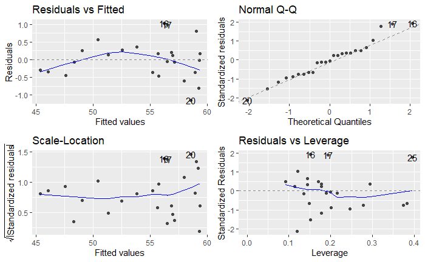

```r
# let's see diagnostic plots
autoplot(mod_auto2)
```

```r
# View summary of the best model (lowest BIC) from the glmulti run above
mod_auto3 <- lm(gdp_phw_usd ~ 1 + ict_bil_usd + cultasset_bil_usd +
                  infrastuct_bil_usd + dwelling_bil_usd +
                  cultasset_bil_usd:ict_bil_usd + dwelling_bil_usd:infrastuct_bil_usd,
                   data = prod_uk_trim)

summary(mod_auto3)
```

```
Call:
lm(formula = gdp_phw_usd ~ 1 + ict_bil_usd + cultasset_bil_usd +
    infrastuct_bil_usd + dwelling_bil_usd + cultasset_bil_usd:ict_bil_usd +
    dwelling_bil_usd:infrastuct_bil_usd, data = prod_uk_trim)

Residuals:
    Min      1Q  Median      3Q     Max
-0.6595 -0.2979 -0.1428  0.1646  1.0839

Coefficients:
                                      Estimate Std. Error t value Pr(>|t|)
(Intercept)                         22.9729453  3.0621277   7.502 6.04e-07 ***
ict_bil_usd                          0.2673784  0.0782419   3.417 0.003071 **
cultasset_bil_usd                    7.7921623  2.3965281   3.251 0.004431 **
infrastuct_bil_usd                   0.0803376  0.0194790   4.124 0.000637 ***
dwelling_bil_usd                     0.2066653  0.0245778   8.409 1.20e-07 ***
ict_bil_usd:cultasset_bil_usd       -0.1263855  0.0421949  -2.995 0.007765 **
infrastuct_bil_usd:dwelling_bil_usd -0.0008769  0.0001570  -5.586 2.66e-05 ***
---
Signif. codes:  0 ‘***’ 0.001 ‘**’ 0.01 ‘*’ 0.05 ‘.’ 0.1 ‘ ’ 1

Residual standard error: 0.5476 on 18 degrees of freedom
Multiple R-squared:  0.9887,    Adjusted R-squared:  0.985
F-statistic:   263 on 6 and 18 DF,  p-value: < 2.2e-16
```

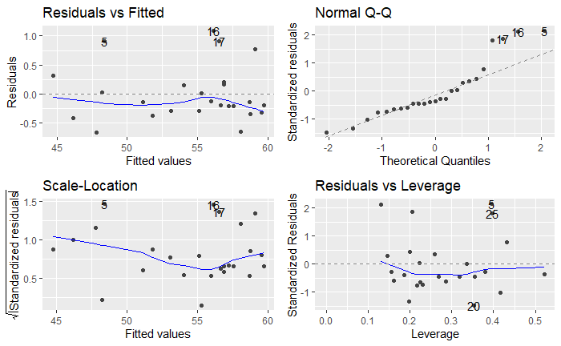

```r
# let's see diagnostic plots
autoplot(mod_auto3)
```

The diagnostic plots don’t look that great, although all predictor coefficients are statistically significant

model_auto2 is a good trade-off between accuracy and model parsimony

```r
library(relaimpo)
calc.relimp(mod_auto2, type = "lmg", rela = TRUE)
```

```
Response variable: gdp_phw_usd
Total response variance: 19.94055
Analysis based on 25 observations

4 Regressors:
infrastuct_bil_usd intelprop_bil_usd dwelling_bil_usd infrastuct_bil_usd:dwelling_bil_usd
Proportion of variance explained by model: 98.62%
Metrics are normalized to sum to 100% (rela=TRUE).

Relative importance metrics:

                                          lmg
infrastuct_bil_usd                  0.3392090
intelprop_bil_usd                   0.1823124
dwelling_bil_usd                    0.3499682
infrastuct_bil_usd:dwelling_bil_usd 0.1285103

Average coefficients for different model sizes:

                                           1X          2Xs          3Xs          4Xs
infrastuct_bil_usd                  0.0956436  0.070723344  0.092790846  0.126098716
intelprop_bil_usd                   0.1522055 -0.008596465 -0.022328081  0.049785353
dwelling_bil_usd                    0.1488264  0.121347416  0.163875966  0.240369357
infrastuct_bil_usd:dwelling_bil_usd       NaN          NaN -0.001210134 -0.001338482
```

**K-fold cross validation**

Cross validation of manually selected model

```r
library(caret)
set.seed(765977)
# set up options for train function below
cv_10_fold <- trainControl(method = "cv", # cross-validation
                           number = 10, # 10-fold
                           savePredictions = TRUE) # save all predictions

model_6e_kfold <- train(gdp_phw_usd ~ dwelling_bil_usd + cultasset_bil_usd +
                          dwelling_bil_usd:cultasset_bil_usd + ict_bil_usd +
                          infrastuct_bil_usd + ict_bil_usd:infrastuct_bil_usd,
                        data = prod_uk_trim,
                        trControl = cv_10_fold, # use options defined above
                        method = 'lm')
```

Cross validation of automatically selected model following some manipulation (mod_auto2)

```r
model_reduced_kfold <- train(gdp_phw_usd ~ 1 + infrastuct_bil_usd +
                               intelprop_bil_usd + dwelling_bil_usd +
                               dwelling_bil_usd:infrastuct_bil_usd,
                             data = prod_uk_trim,
                             trControl = cv_10_fold, # use options defined above
                             method = 'lm')
```

```r
model_reduced_kfold$resample
```

| RMSE | Rsquared | MAE | Resample |
| --- | --- | --- | --- |
| 0.3185902 | 0.9921928 | 0.3080170 | Fold01 |
| 1.0811909 | 0.9998842 | 1.0801300 | Fold02 |
| 0.3979386 | 1.0000000 | 0.2913302 | Fold03 |
| 0.1841823 | 0.9999848 | 0.1448760 | Fold04 |
| 0.9184216 | 1.0000000 | 0.6763375 | Fold05 |
| 0.4662645 | 1.0000000 | 0.3964260 | Fold06 |
| 0.5842674 | 0.9994682 | 0.4730789 | Fold07 |
| 0.7637792 | 0.4585271 | 0.7170698 | Fold08 |
| 0.8606188 | 1.0000000 | 0.6825294 | Fold09 |
| 0.3594567 | 1.0000000 | 0.3505547 | Fold10 |

```r
tibble(
  model = "automatically selected model, then reduced",
  RMSE = mean(model_reduced_kfold$resample$RMSE),
  Rsquared = mean(model_reduced_kfold$resample$Rsquared)
)
```

| model | RMSE | Rsquared |
| --- | --- | --- |
| automatically selected model, then reduced | 0.593471 | 0.9450057 |